# Managing large desktop-sized files

Feb 12, 2016

# 1 Getting started

To follow along, please download the datasets in the previous tutorial, and place all downloaded files in a folder called `data` at the same level as the working directory. Alternatively, you could change `dataPath` in the first code block to point to the location of the data. You could also clone the [repository](https://github.com/bdsegal/BSA-computing-workshop) and run the `download_files.R` script in the `data` folder.

# 2 Managing files

Managing files from within R can be useful in some situations, like making reproducible reports. Let’s see what’s in our data folder.

```r
parent <- dirname(getwd())
dataPath <- file.path(parent, "data")

list.files(dataPath)
```

```
## [1] "download_files.R"  "public_layout.csv" "recs2009.csv"
## [4] "train.csv"         "train.zip"
```

We’re only interested in the csv files, so let’s just look at those. We’ll save the file names so we can use them later.

```r
csvFiles <- list.files(dataPath, pattern = "*.csv$")
csvFiles
```

```
## [1] "public_layout.csv" "recs2009.csv"      "train.csv"
```

Let’s see how large the files are. We’re going to work with the `recs2009.csv` file, which contains data from the [2009 residential energy consumption survey (RECS)](http://www.eia.gov/consumption/residential/data/2009/index.cfm?view=microdata).

```r
setwd(dataPath)
info <- file.info(path = csvFiles)
info
```

```
##                         size isdir mode               mtime
## public_layout.csv      59883 FALSE  666 2016-02-11 19:55:02
## recs2009.csv        27460827 FALSE  666 2016-02-12 10:31:46
## train.csv         1942848724 FALSE  666 2016-02-12 10:45:43
##                                 ctime               atime exe
## public_layout.csv 2016-02-06 18:45:11 2016-02-11 19:55:02  no
## recs2009.csv      2016-02-06 18:50:06 2016-02-06 18:50:06  no
## train.csv         2016-02-12 10:44:48 2016-02-12 10:44:48  no
```

```r
size <- info["recs2009.csv", "size"]
size/1e6
```

```
## [1] 27.46083
```

So the `recs2009.csv` file is 27 MB – a very manageable size.

# 3 Reading in data

Base R functions and data structures, such as `read.csv` and `data.frame`, are fine for most datasets. However, for larger datasets, the `readr` and `data.table` packages are noticeably faster.

```r
# install.packages(c("readr", "data.table"))
library(readr)
library(data.table)
```

At 27 MB, the `recs2009.csv` file isn’t large. However, if we were working with many files of this size, `readr` and `data.table` would save a lot of time.

```r
# Compare read-in times
t_base <- system.time(data <- read.csv(file.path(dataPath, "recs2009.csv")))[3] # base R

t_fread <- system.time(data <- fread(file.path(dataPath, "recs2009.csv"), showProgress = FALSE))[3] # data.table

t_readr <- system.time(data <- read_csv(file.path(dataPath, "recs2009.csv"), progress = FALSE))[3] # readr
compare <- c(t_base, t_readr, t_fread)
names(compare) <- c("read.csv", "read_csv", "fread")

# times relative to read.csv
signif(compare / compare[1], 2)
```

```
## read.csv read_csv    fread
##     1.00     0.17     0.06
```

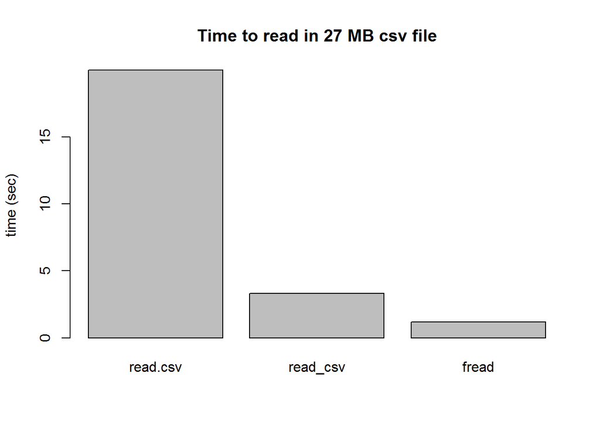

```r
barplot(compare, ylab = "time (sec)",
  main = paste("Time to read in ", round(size/1e6),
  " MB csv file", sep = ""))
```

We downloaded the `recs2009.csv` file earlier to save time, but you can also pass the url directly to `read.csv`, `read_csv`, and `fread`.

`read_csv` had trouble parsing some records. The `tbl_df` object records these problems as an attribute.

```r
head(problems(data))
```

```
## Source: local data frame [6 x 4]
##
##     row         col               expected actual
##   (int)       (chr)                  (chr)  (chr)
## 1  1538 GALLONFOOTH no trailing characters   .724
## 2  1538    BTUFOOTH no trailing characters   .732
## 3  1538    DOLFOOTH no trailing characters   .373
## 4  3628    NUMCORDS no trailing characters     .5
## 5  3981 GALLONFOOTH no trailing characters   .681
## 6  3981    BTUFOOTH no trailing characters   .778
```

Before analyzing the data, we would want to look at the original file and figure out the problem.

Note: read-in times can vary. For a more complete comparison, you could do a simulation study (read in the same data many times to get the means, quantiles, and standard deviations of the read-in times).

Now let’s see what happens with a larger file.

```r
size <- info["train.csv", "size"]
size/1e6
```

```
## [1] 1942.849
```

The `train.csv` file contains the trajectories of 442 taxis in the city of Porto, Portugal for one complete year (from 7/1/2013 to 6/30/2014). The European Conference on Machine Learning and Principles and Practice of Knowledge Discovery in Databases (ECML PKDD) hosted a competition through Kaggle with this dataset last summer. The data are publicly available on the [UCI Machine Learning Repository](https://archive.ics.uci.edu/ml/datasets/Taxi+Service+Trajectory+-+Prediction+Challenge,+ECML+PKDD+2015).

At 1,943 MB, the `train.csv` file is too large for `read.csv`. The following code crashed my computer, which has 8 GB of memory:

```r
# warning: the following might crash your computer
# read.csv(file.path(dataPath, 'train.csv'))
```

However, we can still read in the file with `readr` and `data.table`. We can use the `rm` and `gc` functions to remove large files and return the memory to the operating system (gc for garbage collection). Typically, we only need to call `rm` (see Hadley Wikham’s [Advanced R](http://adv-r.had.co.nz/memory.html)). However, when I monitor memory use with the windows task manager, I don’t see a decrease until after I call `gc`. I don’t know if it helps, but it doesn’t hurt, so sometimes I call `gc` to be safe.

`system.time` calls `gc` by default, so we don’t need `gc` after the first `rm`.

To keep the comparison below fair, I specified the column types. If you don’t specify column types with this example, `read_csv` does a better job at guessing which columns are integers. `fread` guessed that everything was a character string, and actually took longer to read in the data.

```r
t_readr <- system.time(data <- read_csv(file.path(dataPath, 'train.csv'),
  col_types=cols(
    TRIP_ID = col_character(),
    CALL_TYPE = col_character(),
    ORIGIN_CALL = col_integer(),
    ORIGIN_STAND = col_integer(),
    TAXI_ID = col_integer(),
    TIMESTAMP = col_integer(),
    DAY_TYPE = col_character(),
    MISSING_DATA = col_character(),
    POLYLINE = col_character()),
    progress=FALSE)
    )[3]
rm(data)

t_fread <- system.time(data <- fread(file.path(dataPath, 'train.csv'),
  colClasses = c("character", "character", rep("integer", 4), rep("character", 3)),
  showProgress = FALSE)
  )[3]
rm(data)
gc()
```

```
##           used (Mb) gc trigger   (Mb)  max used   (Mb)
## Ncells  421542 22.6    5309345  283.6   5565496  297.3
## Vcells 4782281 36.5  290816354 2218.8 265207694 2023.4
```

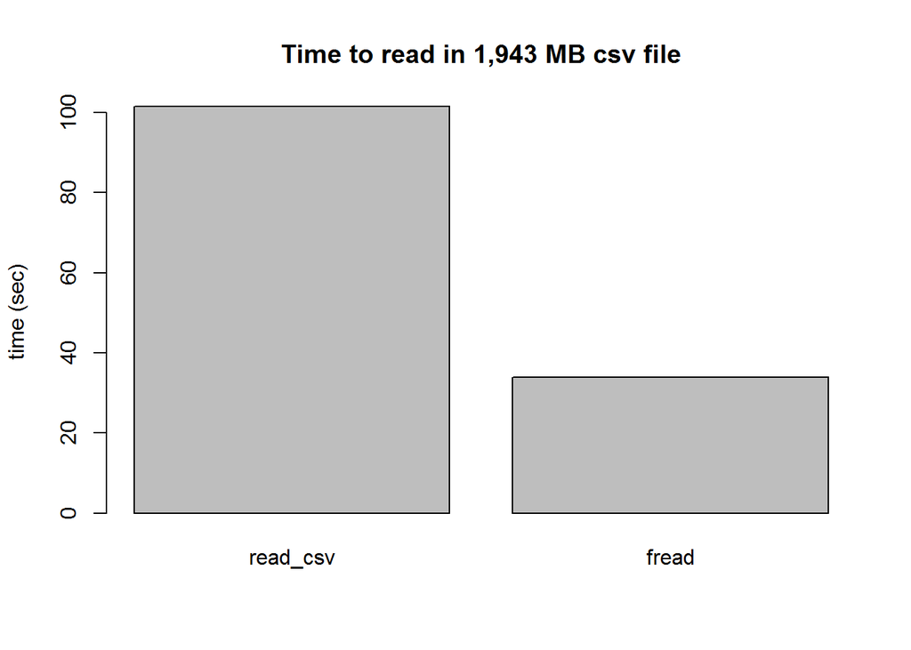

```r
compare <- c(t_readr, t_fread)
names(compare) <- c("read_csv", "fread")

barplot(compare, ylab = "time (sec)",
  main = paste("Time to read in ", prettyNum(round(size / 1e6), big.mark = ","), " MB csv file", sep = ""))
```

`fread` from `data.table` is typically faster than `read_csv` from `readr`. `fread` creates a `data.table` instead of a `data.frame`, which uses different syntax and doesn’t work as well with `dplyr`. I think the syntax is fine, though, and operations with `data.table` are [fast](https://github.com/Rdatatable/data.table/wiki/Benchmarks-%3A-Grouping). If you need to convert a `data.table` to a `data.frame`, you can use the `as.data.frame` function. See Hadley Wickham’s [github page on `readr`](https://github.com/hadley/readr) for more information on `readr`.

# 4 Working with data too large for memory

There are several options for working with datasets too large to fit into memory. As one quick approach, you can use gawk command line tools from within R to read in a subset of the data. This can help you to get a sense for the data before implementing another computing solution, some of which I mention below. We’ll use the `train.csv` dataset, and treat it as if it were too big for memory.

```r
setwd(dataPath)

# read in every 250th line
filePipe <- pipe("gawk 'BEGIN{i=0}{i++; if(i%250==0) print $1}' < train.csv")
system.time(train <- read.table(filePipe, sep = ","))
```

```
##    user  system elapsed
##    4.12   17.12   35.35
```

```r
header <- read.csv("train.csv", nrow = 1)
colnames(train) <- colnames(header)

str(train)
```

```
## 'data.frame':    6842 obs. of  9 variables:
##  $ TRIP_ID     : num  1.37e+18 1.37e+18 1.37e+18 1.37e+18 1.37e+18 ...
##  $ CALL_TYPE   : Factor w/ 3 levels "A","B","C": 3 2 2 3 1 3 2 2 3 2 ...
##  $ ORIGIN_CALL : int  NA NA NA NA 14558 NA NA NA NA NA ...
##  $ ORIGIN_STAND: int  NA 52 61 NA NA NA 15 NA NA 23 ...
##  $ TAXI_ID     : int  20000653 20000076 20000341 20000320 20000432 20000598 20000268 20000451 20000455 20000463 ...
##  $ TIMESTAMP   : int  1372649868 1372662088 1372665287 1372664244 1372669608 1372673543 1372672664 1372678992 1372670258 1372678111 ...
##  $ DAY_TYPE    : Factor w/ 1 level "A": 1 1 1 1 1 1 1 1 1 1 ...
##  $ MISSING_DATA: Factor w/ 1 level "False": 1 1 1 1 1 1 1 1 1 1 ...
##  $ POLYLINE    : Factor w/ 6820 levels "[[-7.787205,41.088267],[-7.783578,41.090211],[-7.782561,41.093874],[-7.781742,41.096961],[-7.779546,41.099697],[-7.776018,41.10"| __truncated__,..: 6084 3482 1224 2028 5796 822 707 4074 2990 3296 ...
```

Gawk is a GNU implementation of awk, a command line file processing tool for Unix. For more information, see the [gawk home page](http://www.gnu.org/software/gawk). Kerby Shedden’s [STAT 506 class notes](http://dept.stat.lsa.umich.edu/~kshedden/Courses/Stat506/large_files/) also have some pointers for using awk.

This is a quick way to peak at large datasets with R. However, the subset might be a biased sample from the full dataset, especially if the variables (columns) have non-random trends across the observations (rows). In some cases, you might be able to repeat the same analysis with multiple samples, and then aggregate the results. Ariel Kleiner, et al.’s [Bag of Little Bootstraps](http://arxiv.org/abs/1112.5016) is an example of this approach. I think it was developed with a distributed computing system in mind, but you could also implement it on desktop.

Depending on your situation, you might also consider:

- Calculating sufficient statistics on a data stream (e.g. by writing a function in C, see Hyun Kang’s [BIOSAT 615 class notes](http://genome.sph.umich.edu/wiki/Biostatistics_615/815:_Main_Page), lecture 14, slides 9-13)
- Converting the data into a Hierarchical Data Format version 5 (HDF5) file and using the `rhdf5` package (see Kerby Shedden’s [STAT 506 class notes](http://dept.stat.lsa.umich.edu/~kshedden/Courses/Stat506/large_files/))
- Storing the dataset in a SQL database, and connecting via `dplyr` or another package (see Hadley Wickham’s [vignette for connecting dplyr to remote databases](https://cran.r-project.org/web/packages/dplyr/vignettes/databases.html)). [`ff`](https://cran.r-project.org/web/packages/ff/index.html) is another package that works with data stored on disk. To fully take advantage of these options, it would help to have a solid state drive (SSD).
- Using a distributed computing system, like Spark or Hadoop (see the schedule of [Advanced Research Computing workshops](http://arc-ts.umich.edu/training-workshops/))
- Using the [`bigmemory`](https://cran.r-project.org/web/packages/bigmemory/index.html) package to more efficiently store matrices in memory.

# 5 Other notes/tips

- When working with large files, you can monitor memory use with the windows task manager.
- The POLYLINE variable in the `train.csv` dataset is in JSON format. You can use an R package, such as `json`, to parse this variable.
- If you want to experiment with terabyte sized data, take a look at the [Amazon Web Services (AWS) public data sets](http://aws.amazon.com/datasets/). You can set up an AWS account (free for the first year, I think) and work with these datasets through AWS.

# 6 Exercises

1. Read in the `train.zip` file directly without unzipping first using `read_csv`. Try to do the same with `fread`. I think you’ll need to insert a command line option into the call, e.g. `'zcat train.zip'` on linux. I’m not sure how to do this on Windows, but let me know if you find a way.
2. Download a gz file (e.g., see the ‘downloading data in R’ tutorial) and read the gz file directly into R without decompressing first. For this, you will need to wrap the file name in `gzfile`, e.g. `read_csv(gzfile(2010.csv.gz))`.
3. Read the `recs2009.csv` file directly from the web by passing the url to `read.csv`, `read_csv`, and `fread`.

Note: I ran all time comparisons with R version 3.2.3 (2015-12-10) on an intel i7 running at 2.67 GHz with 8 GB RAM.

[Computing workshop homepage](http://bdsegal.github.io/BSA-computing-workshop)